# Week09 leafmap

## Interactive Mapping in a Jupyter environment - leafmap

[figure not shown]

[Documentation:](https://leafmap.org/)

## Key features

### Installation

Step 1: Creating a fresh conda environment Run 'Anaconda powershell' as administrator, create a fresh conda environment using the following command:

```
conda create --name name_of_your_virtual_environment
```

Step 2: activate virtual environment

```
conda activate name_of_your_virtual_environment
```

Step 3: Install leafmap from conda-forge to the virtual environment

```
conda install leafmap -c conda-forge
```

### Online Source

[Online official source](https://leafmap.org/installation/)

### Introduction

Leafmap has six plotting backends, including folium, ipyleaflet, plotly, pydeck, kepler.gl, and heremap.

### Load basemaps

```python
import leafmap
m = leafmap.Map(center=(40, -100), zoom=4)
m
```

```
Map(center=[40, -100], controls=(ZoomControl(options=['position', 'zoom_in_text', 'zoom_in_title', 'zoom_out_t…
```

```python
m.to_html(r'F:\Clark_Universiy\Clark_Teaching\sample.html')
```

[output not shown]

[output cut: 37 more lines]

[output not shown]

```python
import leafmap.foliumap as leafmap
```

```python
m = leafmap.Map(location=(45.5236, -122.6750))
m
```

[interactive chart not shown]

```python
m.save(r"F:\Clark_Universiy\Clark_Teaching\sample.html")
```

### MapLibre and Leafmap - 3D Interactive Map

[MapLibre](https://maplibre.org/) is a Open-source TypeScript library for publishing maps on your website.

The MapLibre is Javascript and TypeScript based library that use WebGL to render interactive maps from vector tiles in a browser.

Dr. Qiusheng Wu integrate MapLibre to leafmap so we can use python to generate the maps.

Leafmap, built on top of the py-maplibregl Python package, simplifies the process of creating stunning 3D maps with MapLibre, allowing you to achieve impressive results with just a few lines of code.

#### Create a API key

[MapTiler](https://cloud.maptiler.com/maps/) provide many different vector tile styles that can be used with MapLibre

Sign up a account and generate a API Keys in your account

```python
import os
import leafmap.maplibregl as leafmap
```

[output not shown]

## Time Series

```python
from leafmap import leafmap
url = "https://open.gishub.org/data/landsat/timeseries.zip"
leafmap.download_file(url)
```

```
Downloading...
From: https://open.gishub.org/data/landsat/timeseries.zip
To: f:\Clark_Universiy\Clark_Teaching\Git_Repo\ssj-30262\docs\Lectures\Week9_PythonLeafmap\timeseries.zip
```

```
Extracting files...
```

```
'f:\\Clark_Universiy\\Clark_Teaching\\Git_Repo\\ssj-30262\\docs\\Lectures\\Week9_PythonLeafmap\\timeseries.zip'
```

```python
import os
```

```python
os.getcwd()
```

```
'f:\\Clark_Universiy\\Clark_Teaching\\Git_Repo\\ssj-30262\\docs\\Lectures\\Week9_PythonLeafmap'
```

```python
m = leafmap.Map()
images = "landsat"
m.add_time_slider(
    images,
    time_interval=0.5,
    position="bottomright",
    indexes=[1,2,3],
    zoom_to_layer=True,
)

m
```

[output not shown]

```python
import rasterio
from rasterio.plot import show
import matplotlib.pyplot as plt
```

```python
os.getcwd()
```

```
'f:\\Clark_Universiy\\Clark_Teaching\\Git_Repo\\ssj-30262\\docs\\Lectures\\Week9_PythonLeafmap'
```

```python
tif_file = os.path.join(os.getcwd(), 'landsat\\1984.tif')

with rasterio.open(tif_file) as dataset:
    # Plot the image
    plt.figure(figsize=(8, 8))
    show(dataset)
    plt.title('TIFF Image')
    band_count = dataset.count
    print(band_count)
    # plt.show()
```

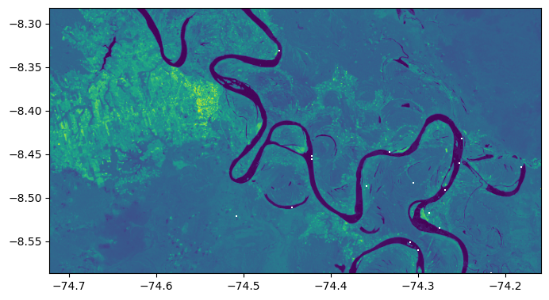

```
3
```

[figure not shown]

### Troubleshoting

- No module named 'localtileserver'

```
conda install -c conda-forge localtileserver
```

- No module named 'rasterio'

```
pip install rasterio
```